# Data Visualization Assignment 1

Denis Tan, dwt2118, Columbia University

January 28, 2015

# 1 Assignment 1

## 1.1 Assignment Summary

We are asked to handle data from the Nigeria MDG Information System (NMIS) to produce a data frame, with meta data, of all healthcare facilities located in the Southern zones of Nigeria. We are then asked to aggregate and compute the absolute and relative (on per capita and per area bases) number of healthcare workers by state.

## 1.2 Preset

I begin the assignment by setting the working directory to the r folder within the local forked repo. Following which, I load the plyr and ggplot2 packages, both of which will be used subsequently.

```r
# Set directory
setwd("~/data-viz/r")

# Load packages
if (!require(plyr)) install.packages("plyr")
        library(plyr)
if (!require(ggplot2)) install.packages("ggplot2")
        library(ggplot2)
```

## 1.3 Read Data

After setting up the R environment, I load the 2 data sets downloaded from the provided website.

```r
# Read data
lgas <- read.csv("lgas.csv")
fac <- read.csv("Health_Mopup_and_Baseline_NMIS_Facility.csv")
```

## 1.4 Merge Data

Next, as requested by the assignment instructions, I used the merge function to combine the 2 data sets using the shared unique identifier for local govenrment areas (unique_lga).

```r
# Combine data sets into single data.frame
df <- merge(lgas, fac, by = "unique_lga")
```

## 1.5 Keep Southern zone Data

After that, I dropped non-Southern zone data by subsetting the data using logical expressions. I also write the data out as “southern_facilities_with_meta_data.csv”.

```r
# Keep only data in the Southern zone
df <- df[df$zone == 'Southeast' | df$zone == 'South-South' | df$zone == 'Southwest',]
write.csv(df, "southern_facilities_with_meta_data.csv")
```

## 1.6 Aggregate by State

Next, as required by the instructions, I use the aggregate function to aggregate 2 variables (number of nurses and number of doctors) at the state level. I do this using the sum function as an argument to the aggregate function. I also aggregate 2 other variables (population size and area) as they will be neede for further data manipulation. I named this data.frame df2 instead of df so that the original data.frame produced would not be altered.

```r
# Aggregate data by state
df2 <- aggregate(cbind(num_nurses_fulltime, num_doctors_fulltime, pop_2006, area_sq_km) ~ state, df, sum, na.rm = TRUE)
```

## 1.7 Create Variables

After that, I create 4 new variables as required by the assignment guidelines. I do so by using the tranform function that calls various columns of the data set.

```r
# Create 4 new variables
df2 <- transform(df2, per_capita_nurses = num_nurses_fulltime/pop_2006)
df2 <- transform(df2, per_area_nurses = num_nurses_fulltime/area_sq_km)
df2 <- transform(df2, per_capita_doctors = num_doctors_fulltime/pop_2006)
df2 <- transform(df2, per_area_doctors = num_doctors_fulltime/area_sq_km)
```

## 1.8 Sort Variables

Immediately after, I sort the variables of each state in decreasing order of population using the arrange function. I also write this second data set out as “healtcare_workers_by_state.csv”

```r
# Sort in descending order of population
df2 <- arrange(df2, desc(pop_2006))
write.csv(df2, "healtcare_workers_by_state.csv")
```

## 1.9 Visualize

Finally, I present the data in 2 different forms. First, I present the sorted data set from above in its tabular form. The data is split into 4 datas for better viewing. Second, I visualize some of the variables in graphical form.

```r
# Visualize
# Tabular
df2[,c(1,4:5)]
```

```
##          state  pop_2006 area_sq_km
## 1        Lagos 558794116   157564.1
## 2         Ogun 281937084   794019.4
## 3          Oyo 228256111   866029.0
## 4      Anambra 194392945   174217.3
## 5          Imo 150709945   198678.1
## 6       Rivers 146739642   248559.6
## 7  Cross River 144852399  1091076.8
## 8        Enugu 143164924   282466.2
## 9          Edo 132872227   569225.7
## 10        Ondo 132585279   579629.3
## 11        Osun 132369063   354761.0
## 12       Delta 132230401   499239.2
## 13        Abia 109546073   179928.0
## 14      Ebonyi  95982233   294450.3
## 15       Ekiti  77503299   171060.2
## 16   Akwa Ibom  68840793   109660.3
## 17     Bayelsa  55916916   299053.3
```

```r
df2[,c(1,2:3)]
```

```
##          state num_nurses_fulltime num_doctors_fulltime
## 1        Lagos                3104                 2652
## 2         Ogun                2138                 1053
## 3          Oyo                1567                  994
## 4      Anambra                1718                  705
## 5          Imo                2120                  917
## 6       Rivers                1090                  670
## 7  Cross River                 387                  253
## 8        Enugu                1117                  520
## 9          Edo                 965                  512
## 10        Ondo                 583                  283
## 11        Osun                 982                  470
## 12       Delta                1157                  638
## 13        Abia                 774                  247
## 14      Ebonyi                 468                  217
## 15       Ekiti                 608                  259
## 16   Akwa Ibom                 612                  251
## 17     Bayelsa                 217                  127
```

```r
df2[,c(1,6:7)]
```

```
##          state per_capita_nurses per_area_nurses
## 1        Lagos      5.554819e-06    0.0196999249
## 2         Ogun      7.583252e-06    0.0026926296
## 3          Oyo      6.865095e-06    0.0018094083
## 4      Anambra      8.837769e-06    0.0098612494
## 5          Imo      1.406676e-05    0.0106705275
## 6       Rivers      7.428122e-06    0.0043852661
## 7  Cross River      2.671685e-06    0.0003546955
## 8        Enugu      7.802190e-06    0.0039544547
## 9          Edo      7.262616e-06    0.0016952853
## 10        Ondo      4.397170e-06    0.0010058152
## 11        Osun      7.418652e-06    0.0027680610
## 12       Delta      8.749879e-06    0.0023175264
## 13        Abia      7.065520e-06    0.0043017198
## 14      Ebonyi      4.875902e-06    0.0015894026
## 15       Ekiti      7.844827e-06    0.0035543039
## 16   Akwa Ibom      8.890078e-06    0.0055808718
## 17     Bayelsa      3.880758e-06    0.0007256231
```

```r
df2[,c(1,8:9)]
```

```
##          state per_capita_doctors per_area_doctors
## 1        Lagos       4.745934e-06     0.0168312503
## 2         Ogun       3.734876e-06     0.0013261641
## 3          Oyo       4.354757e-06     0.0011477676
## 4      Anambra       3.626675e-06     0.0040466710
## 5          Imo       6.084535e-06     0.0046155065
## 6       Rivers       4.565910e-06     0.0026955305
## 7  Cross River       1.746606e-06     0.0002318810
## 8        Enugu       3.632175e-06     0.0018409279
## 9          Edo       3.853326e-06     0.0008994675
## 10        Ondo       2.134475e-06     0.0004882431
## 11        Osun       3.550679e-06     0.0013248357
## 12       Delta       4.824912e-06     0.0012779446
## 13        Abia       2.254759e-06     0.0013727710
## 14      Ebonyi       2.260835e-06     0.0007369666
## 15       Ekiti       3.341793e-06     0.0015140867
## 16   Akwa Ibom       3.646094e-06     0.0022888870
## 17     Bayelsa       2.271227e-06     0.0004246734
```

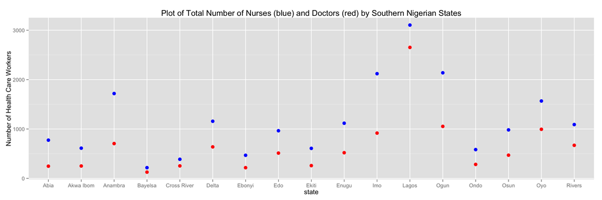

```r
# Absolute variables
ggplot(data = df2, aes(x = state)) +
        geom_point(data = df2, aes(y = num_nurses_fulltime), colour = 'blue', size = 3) +
        geom_point(data = df2, aes(y = num_doctors_fulltime), colour = 'red', size = 3) +
        ylab("Number of Health Care Workers") +
        ggtitle("Plot of Total Number of Nurses (blue) and Doctors (red) by Southern Nigerian States")
```

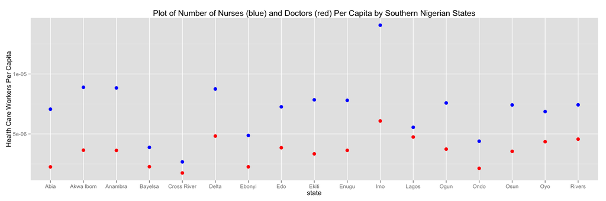

```r
# Relative variables (per population)
ggplot(data = df2, aes(x = state)) +
        geom_point(data = df2, aes(y = per_capita_nurses), colour = 'blue', size = 3) +
        geom_point(data = df2, aes(y = per_capita_doctors), colour = 'red', size = 3) +
        ylab("Health Care Workers Per Capita") +
        ggtitle("Plot of Number of Nurses (blue) and Doctors (red) Per Capita by Southern Nigerian States")
```

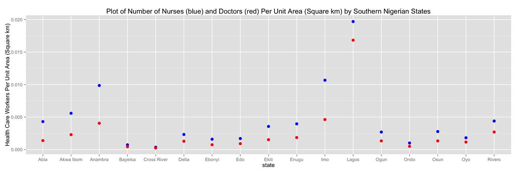

```r
# Relative variables (per area)
ggplot(data = df2, aes(x = state)) +
        geom_point(data = df2, aes(y = per_area_nurses), colour = 'blue', size = 3) +
        geom_point(data = df2, aes(y = per_area_doctors), colour = 'red', size = 3) +
        ylab("Health Care Workers Per Unit Area (Square km)") +
        ggtitle("Plot of Number of Nurses (blue) and Doctors (red) Per Unit Area (Square km) by Southern Nigerian States")
```

## 1.10 End

The assignment has come to an end. Thank you for your attention.